# projected inventories calculation

Nico Nguyen

2022-08-27

# 1) Introduction

## 1.1) The “problem” we aim to solve

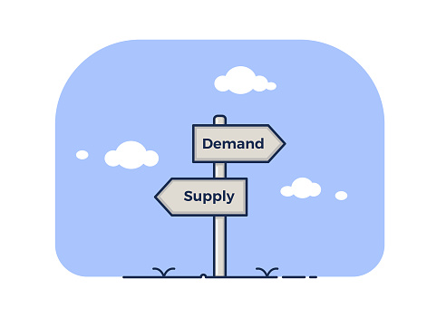

When we work in Demand & Supply Planning, it’s pretty common that we need to calculate **projected inventories** (and related **projected coverages**).  
We often have 3 options to perform this calculation, using:

- an APS (Advanced Planning System) software
- an ERP : for example SAP or JDE
- and of course…Excel!

All are fine, and have different pros and cons.

For example, we simply sometimes don’t have all the data in our ERP either APS, like :

- when we work with third parties Distributors
- or we want to model a supply chain network which relies on different systems with unconnected data

> The idea here is…**how about using R to perform this calculation** ?
- how simple and fast could it be?
- and, could we do more than just the calculation?
  - For example getting (as an output of a function) an analysis of the projected situation of a portfolio?
  - So we don’t have to look at each product one by one, and can instead :
    - easily get a summary view of the portfolio
    - then zoom on the products with risks of shortages or overstocks

## 1.2) Calculation through R

[figure not shown]

> Let’s use 2 functions from the **planr package**:
- **proj_inv()** : to calculate projected inventories and coverages, with also some analysis features
- **light_proj_inv()** : to calculate projected inventories and coverages (only).
  - Runs faster than the previous function (as it’s lighter and doesn’t provide any analysis features).
  - Useful in some cases (see the part “Other Calculations” for example)

Those 2 simple functions can easily be used and combined to perform more complex tasks, such as:

- modeling of a Supply Chain Network
- calculation of projected inventories from raw Materials to Finished Goods
- a multi-echelons distribution network: from a national Distribution Center to Regional Wholesalers to Retailers

Becoming then an useful tool :

- to build easily an End-to-End Supply Chain monitoring
- to support the S&OP (Sales and Operations Planning) process, allowing us to run quickly some scenarios:
  - Change of Sales plan
  - Change of Supply (Production) plan
  - Change of stocks levels parameters
  - Change of Transit Time - etc…

> Moving forward:

This calculation is the basis for a classic second one: **a DRP (Distribution Requirement Planning)** calculation, where, based on some parameters (usually levels of stocks min & max, a reorder quantity and a frozen horizon) we calculate a Replenishment Plan.

More about this other function in another part.

## 1.3) Methodology

### 1.3.1) How to calculate projected inventories

Let’s have a look at the example below, and consider that the field Demand = Sales Forecasts.

We start with some [Opening Inventories] of 1000 units.

- During the month M we sell 100 un (the Demand). At the end of the 1st period (Month M), it remains 900un.
- Then 800un at the end of the following period (Month M+1).
- During the period (Month M+2) we get a Supply of 400un, and sell 100: it remains 1100un in stocks.

That’s all, this how we calculate projected inventories :)

(and what the functions proj_inv() and light_proj_inv() are doing)

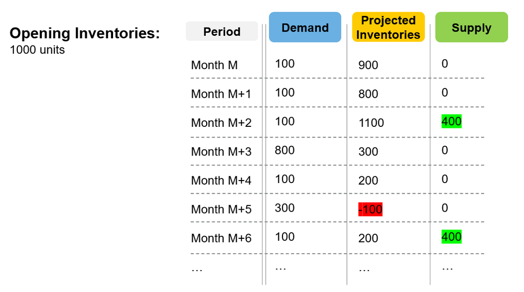

### 1.3.2) How to calculate projected coverages

The idea: we look forward.

We consider the projected inventories we have at the end of a period, and evaluate the related coverage **based on the coming Demand**. See example below:

[figure not shown]

If we use excel, we often see a “shortcut” to estimate the related coverages, like considering an average of the Demand of the next 3 or 6 months.

This can lead to some quite wrong results if the Demand is not constant (if we have some seasonalities or a strong trend for example).

> It becomes very easy through the proj_inv() and light_proj_inv() functions.

# 2) Use Cases : examples

## 2.1) 3rd Party Distributor

We sometimes work with 3rd Parties Distributors to distribute our products. A common question is: how much stocks do our partners hold?

> If we have access to their opening inventories and Sales IN & OUT Forecasts, we can quickly calculate the projected inventories, apply the proj_inv() or light_proj_inv() functions

And then anticipate any risks of shortages or overstocks, and create a collaborative work.

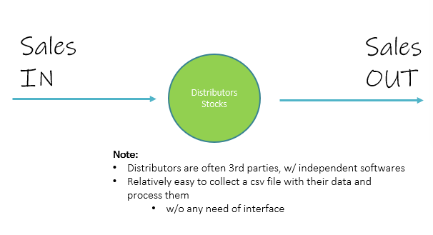

## 2.2) From Raw Materials to Finished Goods

In the example below, we produce olive oil (could be shampoo, liquor, etc).

We start with a first raw material, the olive oil, that we use to fill up different sizes of bottles (35cl, 50cl,…), on which we then apply (stick) a label (and back label).

There are different types of labels, depending on the languages (markets where the products are sold).

Once we have a labelled bottle, we then put it inside an outer box, ready to be shipped, and sold. There are different dimensions of outer boxes, where we can put for example 4, 6 or 12 bottles. T**hey are the Finished Goods.**

We have 2 groups of products here:

- Finished Goods
- Semi-Finished: at different steps, filled bottle (not yet labelled), or labelled bottle

We might me interested in l**ooking at the projected inventories at different levels / steps of the manufacturing process:**

- Finished Goods
- Raw Materials : naked bottles, labels or the liquid (Olive Oil)
- Semi-Finished products

> For this: we can apply the proj_inv() or light_proj_inv() functions on each level of analysis

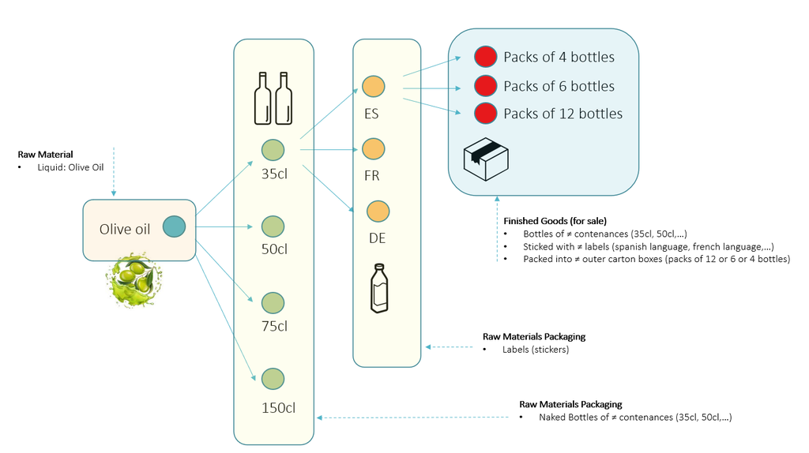

## 2.3) Multi Echelons network

In the example below: we are looking at the distribution network within a country.

The products are stored at different locations:

- at a Central Stock: managed by the company selling the products. For example a National Distribution Center.
- then at some 3rd parties:
  - who buy those products to distribute and sell them in more specific areas, or regions
  - a network of Wholesalers and then Sub-Wholesalers for example

> if we have access to the data of the 3rd parties, such as [Opening Inventories] and [Sales IN & OUT Forecasts], we could apply the proj_inv() or light_proj_inv() functions on each level and visualize the complete projected inventories within the Distribution Network

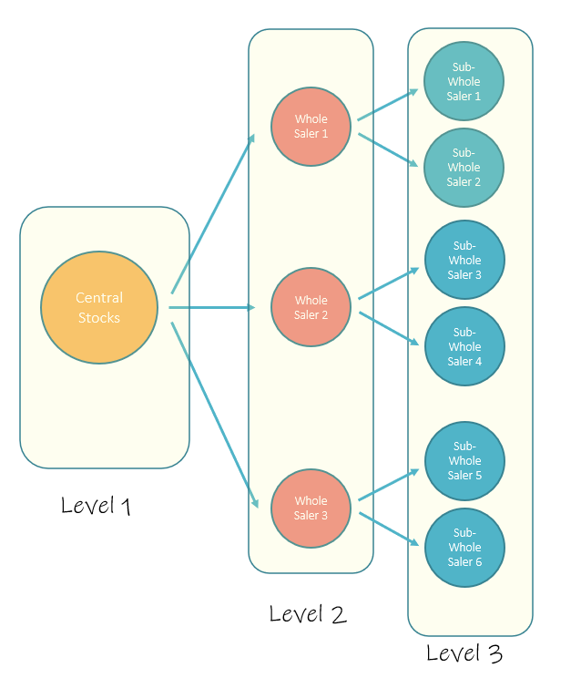

## 2.4) From Production Capacities to Sales

In the example below: we have 1 or several Factories (within the box “Production Capacities”) which supply a [Global Stocks] which is then used to supply directly some markets and a [Regional Stocks].

The [Regional Stocks] is then supplying other markets as well as a 3rd Party Distributor.

**We would like to manage the Monthly S&OP process.**

- Linking Sales & Manufacturing Operations through a simple modeling.
- To balance Demand & Supply over the medium-long term horizon.
- Visualizing some impacts through the whole distribution network

**and make some simulations and drive some decisions :**

- Change of Sales Plan
- Change of Supply Plan
- Change of Inventories Level
- Change of Transit Lead Time
- Change of Product Mix …

> we could apply the proj_inv() or light_proj_inv() functions on each level and visualize the complete projected inventories within the Distribution Network

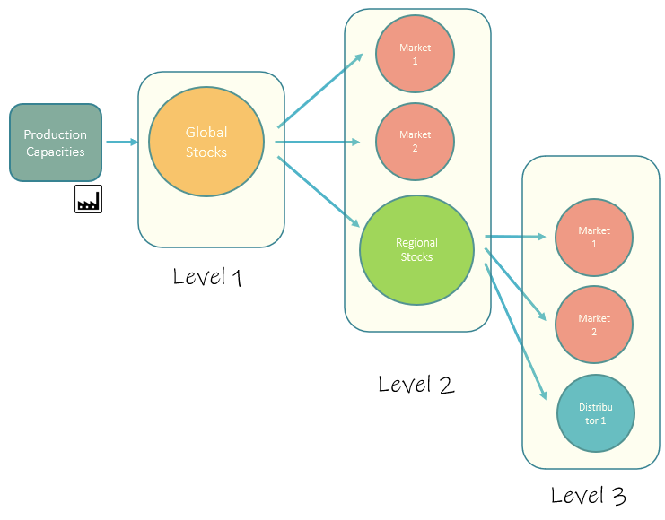

# 3) Overview of the demo dataset

Let’s upload the demo dataset “Blueprint_DB.csv” :

```r
Blueprint_DB <- read_csv("Blueprint_DB.csv",
    col_types = cols(DFU = col_character(),
        Period = col_date(format = "%Y-%m-%d")))


glimpse(Blueprint_DB)
```

```
## Rows: 2,600
## Columns: 7
## $ DFU                 <chr> "Item 000001", "Item 000002", "Item 000003", "Item…
## $ Period              <date> 2022-07-03, 2022-07-03, 2022-07-03, 2022-07-03, 2…
## $ Demand              <dbl> 364, 1419, 265, 1296, 265, 1141, 126, 6859, 66, 38…
## $ Opening.Inventories <dbl> 6570, 5509, 2494, 7172, 1464, 9954, 2092, 17772, 1…
## $ Supply.Plan         <dbl> 0, 0, 0, 0, 0, 0, 0, 0, 0, 0, 0, 0, 0, 0, 0, 0, 0,…
## $ Min.Stocks.Coverage <dbl> 4, 4, 4, 6, 4, 6, 4, 6, 4, 4, 4, 4, 6, 6, 6, 6, 4,…
## $ Max.Stocks.Coverage <dbl> 8, 6, 12, 6, 12, 6, 8, 10, 12, 12, 8, 12, 10, 10, …
```

**The [Blueprint_DB] dataset has 7 fields:**

- **DFU** : stands for “Demand Forecast Unit”.
  - It’s basically one product (also called SKU, “Storage Keeping Unit”), with a little more characteristics, for example a SKU sold in one particular distribution channel
- **Period** : the horizon of time where we are going to project our calculation of inventories.
  - It could be monthly, weekly, daily (and so on) buckets, over a certain range of periods, for example 24 months or 52 weeks.
- **Demand** : the Demand Forecasts for each period of time.
  - Expressed in units.
  - This could be Sales Forecasts or Replenishment Forecasts (if we ship to one warehouse to replenish it) for example.
- **Opening Inventories** : our available stocks at the beginning of the horizon.
  - Expressed in units.
- **Supply Plan** : the quantities that we will receive to replenish our stocks.
  - A certain quantity at a given time.
  - Expressed in units.
- **Min Stocks Coverage** : a parameter of minimum stocks.
  - Expressed in number of periods of coverage.
  - If we put 2 months, it means that we aim to maintain a minimum stocks coverage of 2 months, based on the Demand Forecasts.
- **Max Stocks Coverage** : a parameter of maximum stocks.
  - Expressed in number of periods of coverage.
  - If we put 6 months, it means that we aim to maintain our stocks below a coverage of 6 months, based on the Demand Forecasts.

Let’s explore a bit more the size of the portfolio:

```r
# keep only some needed columns
df1 <- Blueprint_DB %>% select(DFU, Period, Demand)

# spread
df1 <- df1 %>% spread(Period, Demand)

head(df1)
```

```
## # A tibble: 6 × 53
##   DFU    2022-…¹ 2022-…² 2022-…³ 2022-…⁴ 2022-…⁵ 2022-…⁶ 2022-…⁷ 2022-…⁸ 2022-…⁹
##   <chr>    <dbl>   <dbl>   <dbl>   <dbl>   <dbl>   <dbl>   <dbl>   <dbl>   <dbl>
## 1 Item …     364     364     364     260     736     859     859     859     273
## 2 Item …    1419    1419    1419    1014     721     841     841     841    1160
## 3 Item …     265     265     265     189      29      34      34      34      23
## 4 Item …    1296    1296    1296     926     678     791     791     791     560
## 5 Item …     265     265     265     189      59      69      69      69      40
## 6 Item …    1141    1141    1141     815    1466    1711    1711    1711     943
## # … with 43 more variables: `2022-09-04` <dbl>, `2022-09-11` <dbl>,
## #   `2022-09-18` <dbl>, `2022-09-25` <dbl>, `2022-10-02` <dbl>,
## #   `2022-10-09` <dbl>, `2022-10-16` <dbl>, `2022-10-23` <dbl>,
## #   `2022-10-30` <dbl>, `2022-11-06` <dbl>, `2022-11-13` <dbl>,
## #   `2022-11-20` <dbl>, `2022-11-27` <dbl>, `2022-12-04` <dbl>,
## #   `2022-12-11` <dbl>, `2022-12-18` <dbl>, `2022-12-25` <dbl>,
## #   `2023-01-01` <dbl>, `2023-01-08` <dbl>, `2023-01-15` <dbl>, …
```

It’s a portfolio of :

- 50 DFUs (items)
- the field Period is in weekly bucket
- an horizon of time of 52 weeks

Let’s look closer at one product, for example the “Item 000008” :

```r
df1 <- filter(Blueprint_DB, Blueprint_DB$DFU == "Item 000008")

df1
```

```
## # A tibble: 52 × 7
##    DFU         Period     Demand Opening.Inventories Supply.Plan Min.S…¹ Max.S…²
##    <chr>       <date>      <dbl>               <dbl>       <dbl>   <dbl>   <dbl>
##  1 Item 000008 2022-07-03   6859               17772           0       6      10
##  2 Item 000008 2022-07-10   6859                   0           0       6      10
##  3 Item 000008 2022-07-17   6859                   0       12012       6      10
##  4 Item 000008 2022-07-24   4900                   0           0       6      10
##  5 Item 000008 2022-07-31   1358                   0       10000       6      10
##  6 Item 000008 2022-08-07   1585                   0           0       6      10
##  7 Item 000008 2022-08-14   1585                   0           0       6      10
##  8 Item 000008 2022-08-21   1585                   0           0       6      10
##  9 Item 000008 2022-08-28   2023                   0        1453       6      10
## 10 Item 000008 2022-09-04   4191                   0        2244       6      10
## # … with 42 more rows, and abbreviated variable names ¹Min.Stocks.Coverage,
## #   ²Max.Stocks.Coverage
```

We can see the 3 groups of data:

- **Some Dimensions** : [DFU] and [Period]
- **Demand and Supply Planning values** : [Demand] / [Opening Inventories] / [Supply Plan]
- **Stocks Levels** : [Min.Stocks.Coverage] and [Max.Stocks.Coverage]

# 4) Calculation of the Projected Inventories

We are going to calculate 2 things, applying the methodology we saw previously:

- **Projected Inventories**
  - definition: [Stocks at the beginning of a Period of time] - [Demand of the Period] + [Supply Plan to be received during this Period]
  - at the very beginning: [Stocks at the beginning of a Period of time] = [Opening Inventories]
- **Related Projected Coverages**
  - definition: how many periods of Demand (forecasts) do the Projected Inventories of a Period of time cover

## 4.1) Run proj_inv()

> Let’s apply the function proj_inv() to the whole demo dataset

```r
# Get the proj_inv() function
source("proj-inv-function.R")

# Get the light_proj_inv() function
source("light-proj-inv-function.R")
```

```r
# create a calculated database for the Projected Inventories @ DFU level
Calculated_DB <- proj_inv(data = Blueprint_DB,
                    DFU = DFU,
                    Period = Period,
                    Demand =  Demand,
                    Opening.Inventories = Opening.Inventories,
                    Supply.Plan = Supply.Plan,
                    Min.Stocks.Coverage = Min.Stocks.Coverage,
                    Max.Stocks.Coverage = Max.Stocks.Coverage)
```

```
## argument.
## 'Opening.Inventories'. You can override using the `.groups` argument.
```

Let’s have a look at it:

```r
head(Calculated_DB)
```

```
## # A tibble: 6 × 14
## # Groups:   DFU [1]
##   DFU         Period     Demand Openin…¹ Calcu…² Proje…³ Suppl…⁴ Min.S…⁵ Max.S…⁶
##   <chr>       <date>      <dbl>    <dbl>   <dbl>   <dbl>   <dbl>   <dbl>   <dbl>
## 1 Item 000001 2022-07-03    364     6570      17    6206       0       4       8
## 2 Item 000001 2022-07-10    364        0      16    5842       0       4       8
## 3 Item 000001 2022-07-17    364        0      15    5478       0       4       8
## 4 Item 000001 2022-07-24    260        0      14    5218       0       4       8
## 5 Item 000001 2022-07-31    736        0      13    4482       0       4       8
## 6 Item 000001 2022-08-07    859        0      12    3623       0       4       8
## # … with 5 more variables: Safety.Stocks <dbl>, Maximum.Stocks <dbl>,
## #   PI.Index <chr>, Ratio.PI.vs.min <dbl>, Ratio.PI.vs.Max <dbl>, and
## #   abbreviated variable names ¹Opening.Inventories,
## #   ²Calculated.Coverage.in.Periods, ³Projected.Inventories.Qty, ⁴Supply.Plan,
## #   ⁵Min.Stocks.Coverage, ⁶Max.Stocks.Coverage
```

Let’s look closer at one product:

```r
df1 <- as.data.frame(Calculated_DB)

# let's look at the Item 000008
df1 <- filter(df1, df1$DFU == "Item 000008")


# we can also make the horizon of display shorter
df1 <- subset(df1,  df1$Period <= '2022-12-01')


# get Results
Example_DB <- df1

head(Example_DB)
```

```
##           DFU     Period Demand Opening.Inventories
## 1 Item 000008 2022-07-03   6859               17772
## 2 Item 000008 2022-07-10   6859                   0
## 3 Item 000008 2022-07-17   6859                   0
## 4 Item 000008 2022-07-24   4900                   0
## 5 Item 000008 2022-07-31   1358                   0
## 6 Item 000008 2022-08-07   1585                   0
##   Calculated.Coverage.in.Periods Projected.Inventories.Qty Supply.Plan
## 1                            1.6                     10913           0
## 2                            0.6                      4054           0
## 3                            3.9                      9207       12012
## 4                            2.9                      4307           0
## 5                            5.5                     12949       10000
## 6                            4.5                     11364           0
##   Min.Stocks.Coverage Max.Stocks.Coverage Safety.Stocks Maximum.Stocks PI.Index
## 1                   6                  10         23146          35136    Alert
## 2                   6                  10         17872          32468    Alert
## 3                   6                  10         13036          28839    Alert
## 4                   6                  10         12327          29780    Alert
## 5                   6                  10         15160          34263    Alert
## 6                   6                  10         17766          38519    Alert
##   Ratio.PI.vs.min Ratio.PI.vs.Max
## 1            0.47            0.31
## 2            0.23            0.12
## 3            0.71            0.32
## 4            0.35            0.14
## 5            0.85            0.38
## 6            0.64            0.30
```

And have a look at it using the reactable package:

```r
# set a working df
df1 <- Example_DB


# create a reactable
    reactable(df1,

              striped = TRUE, highlight = TRUE, compact = TRUE,
              defaultPageSize = 10,

              columns = list(


                #-----------------------
                # Initial values

                `Demand`= colDef(
                  name = "Demand",
                  format = colFormat(separators = TRUE, digits=0)
                ),

                `Opening.Inventories`= colDef(
                  name = "Opening Inventories",
                  format = colFormat(separators = TRUE, digits=0)
                ),

                `Supply.Plan`= colDef(
                  name = "Supply Plan",
                  format = colFormat(separators = TRUE, digits=0)
                ),



                #-----------------------
                # Calculated Projections


                `Calculated.Coverage.in.Periods`= colDef(
                  name = "Calculated Coverage in Periods",
                  style = list(background = "yellow")
                ),

                `Projected.Inventories.Qty`= colDef(
                  name = "Projected Inventories Qty",
                  format = colFormat(separators = TRUE, digits=0),
                  style = list(background = "yellow")
                ),




                #-----------------------
                # Projected Min & Max

                `Safety.Stocks`= colDef(
                  name = "Safety Stocks",
                  format = colFormat(separators = TRUE, digits=0),
                  style = list(background = "lightgreen")
                ),

                `Maximum.Stocks`= colDef(
                  name = "Maximum Stocks",
                  format = colFormat(separators = TRUE, digits=0),
                  style = list(background = "lightgreen")
                ),



                #-----------------------
                # Analysis Features

                `PI.Index`= colDef(
                  name = "PI Index",
                  style = list(background = "lightblue")
                ),

                `Ratio.PI.vs.min`= colDef(
                  name = "Ratio PI vs min",
                  style = list(background = "lightblue")
                ),

                `Ratio.PI.vs.Max`= colDef(
                  name = "Ratio PI vs Max'",
                  style = list(background = "lightblue")
                )


              ), # close columns lits

              columnGroups = list(
                colGroup(name = "Calculation of Projected Inventories & Coverages",
                         columns = c("Calculated.Coverage.in.Periods",
                                     "Projected.Inventories.Qty")),

                colGroup(name = "Projected Stocks Targets", columns = c("Safety.Stocks",
                                                                 "Maximum.Stocks")),

                colGroup(name = "Analysis Features", columns = c("PI.Index",
                                                                 "Ratio.PI.vs.min",
                                                                 "Ratio.PI.vs.Max"))
              )

    ) # close reactable
```

| DFU | Period | Demand | Opening Inventories | Calculated Coverage in Periods | Projected Inventories Qty | Supply Plan | Min.Stocks.Coverage | Max.Stocks.Coverage | Safety Stocks | Maximum Stocks | PI Index | Ratio PI vs min | Ratio PI vs Max' |
| --- | --- | --- | --- | --- | --- | --- | --- | --- | --- | --- | --- | --- | --- |
| Item 000008 | 2022-07-03 | 6859 | 17772 | 1.6 | 10913 | 0 | 6 | 10 | 23146 | 35136 | Alert | 0.47 | 0.31 |
| Item 000008 | 2022-07-10 | 6859 | 0 | 0.6 | 4054 | 0 | 6 | 10 | 17872 | 32468 | Alert | 0.23 | 0.12 |
| Item 000008 | 2022-07-17 | 6859 | 0 | 3.9 | 9207 | 12012 | 6 | 10 | 13036 | 28839 | Alert | 0.71 | 0.32 |
| Item 000008 | 2022-07-24 | 4900 | 0 | 2.9 | 4307 | 0 | 6 | 10 | 12327 | 29780 | Alert | 0.35 | 0.14 |
| Item 000008 | 2022-07-31 | 1358 | 0 | 5.5 | 12949 | 10000 | 6 | 10 | 15160 | 34263 | Alert | 0.85 | 0.38 |
| Item 000008 | 2022-08-07 | 1585 | 0 | 4.5 | 11364 | 0 | 6 | 10 | 17766 | 38519 | Alert | 0.64 | 0.3 |
| Item 000008 | 2022-08-14 | 1585 | 0 | 3.5 | 9779 | 0 | 6 | 10 | 19411 | 41941 | Alert | 0.5 | 0.23 |
| Item 000008 | 2022-08-21 | 1585 | 0 | 2.5 | 8194 | 0 | 6 | 10 | 23667 | 42808 | Alert | 0.35 | 0.19 |
| Item 000008 | 2022-08-28 | 2023 | 0 | 1.8 | 7624 | 1453 | 6 | 10 | 27485 | 44217 | Alert | 0.28 | 0.17 |
| Item 000008 | 2022-09-04 | 4191 | 0 | 1.4 | 5677 | 2244 | 6 | 10 | 29135 | 43458 | Alert | 0.19 | 0.13 |

[output cut: 12 more lines]

> After Calculation using proj_inv(), we got 2 new groups of columns, giving us a complete database for an automated analysis (more about it later on).
- **1st group: some calculated columns**
  - calculation of Projected Inventories & Coverages : the basics of the calculation
  - projected Stocks Targets (min & Max) in units : useful for further analysis (below)
- **2nd group: some Analysis Features**
  - to automate the screening and facilitate the decistion taking process:
    - Projected Inventories Index: basically, how are the [projected inventories] (OK, alert, shortage, overstocks)
    - a ratio [Projected Inventories] vs [Minimum Stocks Target] : used w/ a threshold filter, allows to quickly identify the relevant SKUs
    - a ratio [Projected Inventories] vs [Maximum Stocks Target] : same w/ above

## 4.2) Let’s make a better visual

The previous table looked full of nice and useful columns, but well, it’s not super appealing when we look at it :)

So let’s make it a bit nicer.

### 4.2.1) Display of the complete calculated table

For a selected item.

Through the calculated fields [Analysis Features], we have several information available, which are useful for a mass analysis, when we want to build a Cockpit or a Supply Risks Alarm for example.

Let’s keep those fields here.

First, we can create a little function that we will use inside the next table:

```r
#--------------------------------------------------------------------------------------
#    A Function for the status_PI.Index
#--------------------------------------------------------------------------------------

# create a function status.PI.Index
status_PI.Index <- function(color = "#aaa", width = "0.55rem", height = width) {
  span(style = list(
    display = "inline-block",
    marginRight = "0.5rem",
    width = width,
    height = height,
    backgroundColor = color,
    borderRadius = "50%"
  ))
}
```

Now let’s create a reactable:

```r
# set a working df
df1 <- Example_DB



#-------------------------
# Transform

# remove not needed column
df1 <- df1[ , -which(names(df1) %in% c("DFU"))]


# create a f_colorpal field
df1 <- df1 %>% mutate(f_colorpal = case_when( Calculated.Coverage.in.Periods > 8 ~ "#FFA500",
                                                  Calculated.Coverage.in.Periods > 2 ~ "#32CD32",
                                                  Calculated.Coverage.in.Periods > 0 ~ "#FFFF99",
                                                  TRUE ~ "#FF0000" ))



    #-------------------------
    # Create Table



    reactable(df1, resizable = TRUE, showPageSizeOptions = TRUE,

              striped = TRUE, highlight = TRUE, compact = TRUE,
              defaultPageSize = 20,

              columns = list(




                Demand = colDef(
                  name = "Demand (units)",

                  cell = data_bars(df1,
                                   fill_color = "#3fc1c9",
                                   text_position = "outside-end"
                  )

                ),






                Calculated.Coverage.in.Periods = colDef(
                  name = "Coverage (Periods)",
                  maxWidth = 90,

                  cell= color_tiles(df1, color_ref = "f_colorpal")
                ),


                f_colorpal = colDef(show = FALSE), # hidden, just used for the coverages



                `Projected.Inventories.Qty`= colDef(
                  name = "Projected Inventories (units)",
                  format = colFormat(separators = TRUE, digits=0),

                  style = function(value) {
                    if (value > 0) {
                      color <- "#008000"
                    } else if (value < 0) {
                      color <- "#e00000"
                    } else {
                      color <- "#777"
                    }
                    list(color = color
                         #fontWeight = "bold"
                    )
                  }
                ),





                Supply.Plan = colDef(
                  name = "Supply (units)",
                  cell = data_bars(df1,

                                   #round_edges = TRUE
                                   #value <- format(value, big.mark = ","),
                                   #number_fmt = big.mark = ",",
                                   fill_color = "#3CB371",
                                   #fill_opacity = 0.8,
                                   text_position = "outside-end"
                  )
                ),



                PI.Index = colDef(
                  name = "Analysis",

                  cell = function(value) {
                    color <- switch(
                      value,
                      TBC = "hsl(154, 3%, 50%)",
                      OverStock = "hsl(214, 45%, 50%)",
                      OK = "hsl(154, 64%, 50%)",
                      Alert = "hsl(30, 97%, 70%)",
                      Shortage = "hsl(3, 69%, 50%)"
                    )
                    PI.Index <- status_PI.Index(color = color)
                    tagList(PI.Index, value)
                  }),



                `Safety.Stocks`= colDef(
                  name = "Safety Stocks (units)",
                  format = colFormat(separators = TRUE, digits=0)
                ),

                `Maximum.Stocks`= colDef(
                  name = "Maximum Stocks (units)",
                  format = colFormat(separators = TRUE, digits=0)
                ),

                `Opening.Inventories`= colDef(
                  name = "Opening Inventories (units)",
                  format = colFormat(separators = TRUE, digits=0)
                ),


                `Min.Stocks.Coverage`= colDef(name = "Min Stocks Coverage (Periods)"),

                `Max.Stocks.Coverage`= colDef(name = "Maximum Stocks Coverage (Periods)"),


                # ratios
                `Ratio.PI.vs.min`= colDef(name = "Ratio PI vs min"),

                `Ratio.PI.vs.Max`= colDef(name = "Ratio PI vs Max")




              ), # close columns lits

              columnGroups = list(
                colGroup(name = "Projected Inventories", columns = c("Calculated.Coverage.in.Periods",
                                                                     "Projected.Inventories.Qty")),

                colGroup(name = "Stocks Levels Parameters", columns = c("Min.Stocks.Coverage",
                                                                        "Max.Stocks.Coverage",
                                                                        "Safety.Stocks",
                                                                        "Maximum.Stocks")),

                colGroup(name = "Analysis Features", columns = c("PI.Index",
                                                                        "Ratio.PI.vs.min",
                                                                        "Ratio.PI.vs.Max"))

              )

    ) # close reactable
```

| Period | Demand (units) | Opening Inventories (units) | Coverage (Periods) | Projected Inventories (units) | Supply (units) | Min Stocks Coverage (Periods) | Maximum Stocks Coverage (Periods) | Safety Stocks (units) | Maximum Stocks (units) | Analysis | Ratio PI vs min | Ratio PI vs Max |
| --- | --- | --- | --- | --- | --- | --- | --- | --- | --- | --- | --- | --- |
| 2022-07-03 | 6859 | 17772 | 1.6 | 10913 | 0 | 6 | 10 | 23146 | 35136 | Alert | 0.47 | 0.31 |
| 2022-07-10 | 6859 | 0 | 0.6 | 4054 | 0 | 6 | 10 | 17872 | 32468 | Alert | 0.23 | 0.12 |
| 2022-07-17 | 6859 | 0 | 3.9 | 9207 | 12012 | 6 | 10 | 13036 | 28839 | Alert | 0.71 | 0.32 |
| 2022-07-24 | 4900 | 0 | 2.9 | 4307 | 0 | 6 | 10 | 12327 | 29780 | Alert | 0.35 | 0.14 |
| 2022-07-31 | 1358 | 0 | 5.5 | 12949 | 10000 | 6 | 10 | 15160 | 34263 | Alert | 0.85 | 0.38 |
| 2022-08-07 | 1585 | 0 | 4.5 | 11364 | 0 | 6 | 10 | 17766 | 38519 | Alert | 0.64 | 0.3 |
| 2022-08-14 | 1585 | 0 | 3.5 | 9779 | 0 | 6 | 10 | 19411 | 41941 | Alert | 0.5 | 0.23 |
| 2022-08-21 | 1585 | 0 | 2.5 | 8194 | 0 | 6 | 10 | 23667 | 42808 | Alert | 0.35 | 0.19 |
| 2022-08-28 | 2023 | 0 | 1.8 | 7624 | 1453 | 6 | 10 | 27485 | 44217 | Alert | 0.28 | 0.17 |
| 2022-09-04 | 4191 | 0 | 1.4 | 5677 | 2244 | 6 | 10 | 29135 | 43458 | Alert | 0.19 | 0.13 |

[output cut: 12 more lines]

It looks nicer ! …but yes, perhaps it’s too detailed for a focus on a SKU.

An alternative could be:

- a more compact table
- and some charts aside

> Let’s see the Compact view for a more simple display.

### 4.2.2) A more compact view

#### Minimalistic Table

We just keep the most “useful” fields:

```r
# get data
df1 <- Example_DB



#-------------------------
# Transform

# keep only the needed columns
df1 <- df1 %>% select(Period,
                          Demand,
                          Calculated.Coverage.in.Periods,
                          Projected.Inventories.Qty,
                          Supply.Plan)


# create a f_colorpal field

df1$Calculated.Coverage.in.Periods <- as.numeric(df1$Calculated.Coverage.in.Periods)

df1 <- df1 %>% mutate(f_colorpal = case_when( Calculated.Coverage.in.Periods > 8 ~ "#FFA500",
                                                  Calculated.Coverage.in.Periods > 2 ~ "#32CD32",
                                                  Calculated.Coverage.in.Periods > 0 ~ "#FFFF99",
                                                  TRUE ~ "#FF0000" ))






#-------------------------
# Create Table



    reactable(df1, resizable = TRUE, showPageSizeOptions = TRUE,

              striped = TRUE, highlight = TRUE, compact = TRUE,
              defaultPageSize = 20,

              columns = list(



                Demand = colDef(
                  name = "Demand (units)",

                  cell = data_bars(df1,
                                   fill_color = "#3fc1c9",
                                   text_position = "outside-end"
                  )

                ),


              Calculated.Coverage.in.Periods = colDef(
                name = "Coverage (Periods)",
                maxWidth = 90,

                cell= color_tiles(df1, color_ref = "f_colorpal")
              ),


              f_colorpal = colDef(show = FALSE), # hidden, just used for the coverages



                `Projected.Inventories.Qty`= colDef(
                  name = "Projected Inventories (units)",
                  format = colFormat(separators = TRUE, digits=0),

                  style = function(value) {
                    if (value > 0) {
                      color <- "#008000"
                    } else if (value < 0) {
                      color <- "#e00000"
                    } else {
                      color <- "#777"
                    }
                    list(color = color
                         #fontWeight = "bold"
                    )
                  }
                ),




              Supply.Plan = colDef(
                name = "Supply (units)",
                cell = data_bars(df1,
                                 fill_color = "#3CB371",
                                 text_position = "outside-end"
                                 )
                )





              ), # close columns lits

              columnGroups = list(
                colGroup(name = "Projected Inventories", columns = c("Calculated.Coverage.in.Periods",
                                                                     "Projected.Inventories.Qty"))


              )

    ) # close reactable
```

| Period | Demand (units) | Coverage (Periods) | Projected Inventories (units) | Supply (units) |
| --- | --- | --- | --- | --- |
| 2022-07-03 | 6859 | 1.6 | 10913 | 0 |
| 2022-07-10 | 6859 | 0.6 | 4054 | 0 |
| 2022-07-17 | 6859 | 3.9 | 9207 | 12012 |
| 2022-07-24 | 4900 | 2.9 | 4307 | 0 |
| 2022-07-31 | 1358 | 5.5 | 12949 | 10000 |
| 2022-08-07 | 1585 | 4.5 | 11364 | 0 |
| 2022-08-14 | 1585 | 3.5 | 9779 | 0 |
| 2022-08-21 | 1585 | 2.5 | 8194 | 0 |
| 2022-08-28 | 2023 | 1.8 | 7624 | 1453 |
| 2022-09-04 | 4191 | 1.4 | 5677 | 2244 |

[output cut: 12 more lines]

#### And some Charts

We can display some projected inventories, using the highcharter package.

For example here a projection vs minimum and maximum stocks targets:

```r
# get data
df1 <- Example_DB



#---------------------------------
# chart
    p <- highchart() %>%
      hc_add_series(name = "Max", color = "crimson", data = df1$Maximum.Stocks) %>%
      hc_add_series(name = "min", color = "lightblue", data = df1$Safety.Stocks) %>%
      hc_add_series(name = "Projected Inventories", color = "gold", data = df1$Projected.Inventories.Qty) %>%

      hc_title(text = "Projected Inventories") %>%
      hc_subtitle(text = "in units") %>%
      hc_xAxis(categories = df1$Period) %>%
      #hc_yAxis(title = list(text = "Sales (units)")) %>%
      hc_add_theme(hc_theme_google())

    p
```

[interactive chart not shown]

Or here a more visual projection of the inventories, showing the Shortages, if any:

```r
#-------------------------
# get data
df1 <- Example_DB




#-------------------------
# Transform

#-------------------------
# keep only needed columns and reorder
df1<-df1[,c("Period","Projected.Inventories.Qty")]

# create a value.index
df1$Value.Index <- if_else(df1$Projected.Inventories.Qty < 0, "Shortage", "Stock")


# spread
df1<-df1 %>% spread(Value.Index, Projected.Inventories.Qty)


#----------------------------------------------------
# Chart

    u<-highchart() %>%
      hc_title(text = "Projected Inventories") %>%
      hc_subtitle(text = "in units") %>%
      hc_add_theme(hc_theme_google()) %>%

      hc_xAxis(categories = df1$Period) %>%

      hc_add_series(name = "Stock",
                    color = "#32CD32",
                    #dataLabels = list(align = "center", enabled = TRUE),
                    data = df1$Stock) %>%

      hc_add_series(name = "Shortage",
                    color = "#dc3220",
                    #dataLabels = list(align = "center", enabled = TRUE),
                    data = df1$Shortage) %>%

      hc_chart(type = "column") %>%
      hc_plotOptions(series = list(stacking = "normal"))

    u
```

[interactive chart not shown]

# 5) Let’s use the Analysis Features!

We saw that we have 3 fields related to the “Analysis Features”:

- **a PI Index :** indicates us whether the projected inventories over a defined horizon present
  - an Alert : we are below the minimum Stocks Target
  - a Shortage : no more stocks
  - OK : projected stocks are between the targeted minimum and maximum levels. No problems!
  - an OverStock situation : we are above the Maximum Stocks Target
- **a [Ratio PI vs minimum Stocks Targets] :**
  - useful to quantify by how much (in %) we are below the minimum Stocks Target
- **a [Ratio PI vs Maximum Stocks Targets] :**
  - useful to quantify by how much (in %) we are above the Maximum Stocks Target

*Where PI stands for “Projected Inventories”.*

> Let’s use those features to build a Cockpit and a Supply Risks Alarm (they make the task very easy!).

## 5.1) Build a Cockpit

Here is an example of Cockpit with 4 parts.

Before, let’s subset our data:

- selecting a certain horizon of analysis
- and also eventually a certain group of products

```r
# get data
df1 <- Calculated_DB

#-------------------------
# Filters

# subset Period based on those Starting and Ending Periods
df1 <- subset(df1,df1$Period >= '2022-07-03' & df1$Period <= '2022-12-30' )


#-------------------
# Keep Initial_DB
#-------------------

Initial_DB <- df1
```

Now, let’s build our cockpit.

### 5.1.1) Summary

We can start with a first part:

```r
#-------------------------
# Transform


#-------------------
# Create Value_DB
#-------------------

# aggregation
df1 <- Initial_DB %>% select(DFU, Demand, Opening.Inventories) %>%
      group_by(DFU) %>%
      summarise(Total.Demand = sum(Demand),
                Opening.Inventories = sum(Opening.Inventories)
      )

# Get results
Value_DB <- df1


# Create a dataframe w/ a dummy row
DFU <- c("dummy")
Total.Demand <- c(0)
Opening.Inventories <- c(0)

Dummy_DB <- data.frame(DFU, Total.Demand, Opening.Inventories)

# Add Row
Value_DB <- rbind(Value_DB, Dummy_DB)

glimpse(Value_DB)
```

```
## Rows: 51
## Columns: 3
## $ DFU                 <chr> "Item 000001", "Item 000002", "Item 000003", "Item…
## $ Total.Demand        <dbl> 11590, 24539, 2425, 26267, 2364, 34430, 5671, 9517…
## $ Opening.Inventories <dbl> 6570, 5509, 2494, 7172, 1464, 9954, 2092, 17772, 1…
```

This is a summary of some interesting values by products:

- Total Demand (over a selected horizon)
- Opening inventories

It’s often useful if we want to sort / look at the main products in terms of sales or volumes.

### 5.1.2) Supply Risks Alarm

We then can continue with a summary of a Supply Risks Alarm (SRA).

The approach is simple: we look at the different values of the PI.Index over the selected horizon and just display a summary table:

```r
#-------------------
# Create SRA Summary
#-------------------


#-------------------
# Create a Dummy database
# to ensure that all the different values of PI.Index appear, whatever SKU we select
DFU <- c("dummy", "dummy", "dummy", "dummy")
PI.Index <- c("Alert", "OK", "OverStock", "Shortage")

Dummy_DB <- data.frame(DFU, PI.Index)

# add it to Initial
df1 <- Initial_DB %>% select(DFU, PI.Index)
df1 <- rbind(df1, Dummy_DB)



# aggregation
df1 <- df1 %>% select(DFU, PI.Index) %>%
      group_by(DFU, PI.Index) %>%
      summarise(Nb.Occurences = n()
      )
```

```
## argument.
```

```r
# spread data
df1 <- df1 %>% spread(PI.Index, Nb.Occurences)

# replace missing values (NA) by zero
df1[is.na(df1)] <- 0


# Get results
SRA_Summary_DB <- df1



head(SRA_Summary_DB)
```

```
## # A tibble: 6 × 5
## # Groups:   DFU [6]
##   DFU         Alert    OK OverStock Shortage
##   <chr>       <int> <int>     <int>    <int>
## 1 dummy           1     1         1        1
## 2 Item 000001     0     5        21        0
## 3 Item 000002    10     6         3        7
## 4 Item 000003     0     0        26        0
## 5 Item 000004    11     1         5        9
## 6 Item 000005     1    10        15        0
```

The result is a compact table, which informs us whether we need to have a deeper look at one product. **Basically, if we see and Alert, a Shortage or an OverStock situation.**

Moving forward, we can link the 2 previous databases:

```r
#-------------------
# Merge both databases
#-------------------

# merge
df1 <- left_join(Value_DB, SRA_Summary_DB)
# remove the rows related to dummy
df1 <- subset(df1, DFU!="dummy")

# Get Results
Interim_DB <- df1


head(Interim_DB)
```

```
## # A tibble: 6 × 7
##   DFU         Total.Demand Opening.Inventories Alert    OK OverStock Shortage
##   <chr>              <dbl>               <dbl> <int> <int>     <int>    <int>
## 1 Item 000001        11590                6570     0     5        21        0
## 2 Item 000002        24539                5509    10     6         3        7
## 3 Item 000003         2425                2494     0     0        26        0
## 4 Item 000004        26267                7172    11     1         5        9
## 5 Item 000005         2364                1464     1    10        15        0
## 6 Item 000006        34430                9954     9     0        13        4
```

Let’s now make it a bit nicer and insightful, using some sparklines, to visualize:

- the Demand
- the Projected Inventories

### 5.1.3) Sparklines for Demand

```r
#-------------------
# Create Sparklines for Demand
#-------------------



# replace missing values by zero
Initial_DB$Demand[is.na(Initial_DB$Demand)] <- 0

# aggregate
df1 <- Initial_DB %>%
      group_by(
        DFU,
        Period
      ) %>%
      summarise(
        Quantity =sum(Demand)
      )
```

```
## argument.
```

```r
# generate Sparkline
Sparkline_DB <- df1 %>%
      group_by(DFU) %>%
      summarise(Quantity = list(Quantity))



#----------------------------------------
# Link both databases

df1 <- left_join(Interim_DB, Sparkline_DB)
# Get Results
Interim_DB <- df1




glimpse(Interim_DB)
```

```
## Rows: 50
## Columns: 8
## $ DFU                 <chr> "Item 000001", "Item 000002", "Item 000003", "Item…
## $ Total.Demand        <dbl> 11590, 24539, 2425, 26267, 2364, 34430, 5671, 9517…
## $ Opening.Inventories <dbl> 6570, 5509, 2494, 7172, 1464, 9954, 2092, 17772, 1…
## $ Alert               <int> 0, 10, 0, 11, 1, 9, 7, 14, 5, 0, 3, 0, 7, 1, 10, 1…
## $ OK                  <int> 5, 6, 0, 1, 10, 0, 8, 0, 17, 0, 6, 10, 12, 0, 2, 5…
## $ OverStock           <int> 21, 3, 26, 5, 15, 13, 4, 0, 4, 26, 17, 16, 7, 0, 0…
## $ Shortage            <int> 0, 7, 0, 9, 0, 4, 7, 12, 0, 0, 0, 0, 0, 25, 14, 6,…
## $ Quantity            <list> <364, 364, 364, 260, 736, 859, 859, 859, 273, 349…
```

### 5.1.4) Sparklines for Projected Inventories

```r
#-------------------
# Create Sparklines for the Projected Inventories
#-------------------



# replace missing values by zero
Initial_DB$Projected.Inventories.Qty[is.na(Initial_DB$Projected.Inventories.Qty)] <- 0

# aggregate
df1 <- Initial_DB %>%
      group_by(
        DFU,
        Period
      ) %>%
      summarise(
        Quantity =sum(Projected.Inventories.Qty)
      )
```

```
## argument.
```

```r
    # generate Sparkline
    PI.Sparkline_DB <- df1 %>%
      group_by(DFU) %>%
      summarise(PI.Quantity = list(Quantity))




#----------------------------------------
# Link both databases
df1 <- left_join(Interim_DB, PI.Sparkline_DB)
glimpse(df1)
```

```
## Rows: 50
## Columns: 9
## $ DFU                 <chr> "Item 000001", "Item 000002", "Item 000003", "Item…
## $ Total.Demand        <dbl> 11590, 24539, 2425, 26267, 2364, 34430, 5671, 9517…
## $ Opening.Inventories <dbl> 6570, 5509, 2494, 7172, 1464, 9954, 2092, 17772, 1…
## $ Alert               <int> 0, 10, 0, 11, 1, 9, 7, 14, 5, 0, 3, 0, 7, 1, 10, 1…
## $ OK                  <int> 5, 6, 0, 1, 10, 0, 8, 0, 17, 0, 6, 10, 12, 0, 2, 5…
## $ OverStock           <int> 21, 3, 26, 5, 15, 13, 4, 0, 4, 26, 17, 16, 7, 0, 0…
## $ Shortage            <int> 0, 7, 0, 9, 0, 4, 7, 12, 0, 0, 0, 0, 0, 25, 14, 6,…
## $ Quantity            <list> <364, 364, 364, 260, 736, 859, 859, 859, 273, 349…
## $ PI.Quantity         <list> <6206, 5842, 5478, 5218, 4482, 3623, 2764, 1905, …
```

### 5.1.5) Visualize

```r
# Reorder Columns
df1 <- df1 %>% select(DFU,
                          Opening.Inventories,
                          Total.Demand,
                          Quantity,
                          OK,
                          OverStock,
                          Alert,
                          Shortage,
                          PI.Quantity)
```

We will use a reactable

```r
reactable(df1,compact = TRUE,

              defaultSortOrder = "desc",
              defaultSorted = c("Total.Demand"),
              defaultPageSize = 10,

              columns = list(

                `DFU` = colDef(name = "Item", minWidth = 150),



                `Opening.Inventories`= colDef(
                  name = "Opening Inventories (units)",
                  aggregate = "sum", footer = function(values) formatC(sum(values),format="f", big.mark=",", digits=0),
                  format = colFormat(separators = TRUE, digits=0)
                  #style = list(background = "yellow",fontWeight = "bold")
                ),


                `Total.Demand`= colDef(
                  name = "Total Demand (units)",
                  aggregate = "sum", footer = function(values) formatC(sum(values),format="f", big.mark=",", digits=0),
                  format = colFormat(separators = TRUE, digits=0),
                  style = list(background = "yellow",fontWeight = "bold")
                ),


                Quantity = colDef(
                  name = "Demand",
                  cell = function(value, index) {
                    sparkline(df1$Quantity[[index]])
                  }),



                PI.Quantity = colDef(
                  name = "Projected Inventories",
                  cell = function(values) {
                    sparkline(values, type = "bar"
                    )
                  })





              ), # close columns list

              defaultColDef = colDef(footerStyle = list(fontWeight = "bold")),

              columnGroups = list(

                colGroup(name = "Demand Overview",
                         columns = c("Total.Demand", "Quantity")),

                colGroup(name = "Projected Inventories Analysis",
                         columns = c("OK", "OverStock", "Alert", "Shortage", "PI.Quantity"))


              )

    ) # close reactable
```

| Item | Opening Inventories (units) | Total Demand (units) | Demand | OK | OverStock | Alert | Shortage | Projected Inventories |
| --- | --- | --- | --- | --- | --- | --- | --- | --- |
| Item 000001 | 6570 | 11590 | [364, 364, 364, 260, 736, 859, 859, 859, 273, 349, 349, 349, 200, 0, 0, 0, 0, 367, 514, 514, 514, 506, 837, 837, 837, 479] | 5 | 21 | 0 | 0 | [6206, 5842, 5478, 5218, 4482, 3623, 2764, 1905, 1632, 1283, 934, 585, 385, 385, 12001, 12001, 12001, 11634, 11120, 10606, 10092, 9586, 9936, 9099, 8262, 7783] |
| Item 000002 | 5509 | 24539 | [1419, 1419, 1419, 1014, 721, 841, 841, 841, 1160, 2427, 2427, 2427, 1502, 807, 807, 807, 692, 510, 714, 714, 714, 216, 28, 28, 28, 16] | 6 | 3 | 10 | 7 | [4090, 2671, 1252, 10605, 9884, 9043, 8202, 7361, 10954, 8527, 6100, 3673, 2171, 3308, 3148, 2341, 1649, 1139, 425, -289, -1003, -1219, -1031, -1059, -1087, -1103] |
| Item 000003 | 2494 | 2425 | [265, 265, 265, 189, 29, 34, 34, 34, 23, 42, 42, 42, 50, 178, 178, 178, 152, 24, 34, 34, 34, 41, 72, 72, 72, 42] | 0 | 26 | 0 | 0 | [2229, 8697, 8432, 8243, 8214, 8180, 8146, 8112, 8089, 8047, 8005, 7963, 7913, 7735, 7557, 7379, 7227, 7203, 7169, 7135, 7101, 7060, 6988, 6916, 6844, 6802] |
| Item 000004 | 7172 | 26267 | [1296, 1296, 1296, 926, 678, 791, 791, 791, 560, 1042, 1042, 1042, 785, 1329, 1329, 1329, 1139, 1452, 2032, 2032, 2032, 653, 169, 169, 169, 97] | 1 | 5 | 11 | 9 | [5876, 4580, 3284, 2358, 1680, 889, 98, 11020, 10460, 9418, 8376, 7334, 6549, 5220, 3891, 2562, 1423, -29, -2061, -4093, -125, -778, -947, -1116, -1285, -1382] |
| Item 000005 | 1464 | 2364 | [265, 265, 265, 189, 59, 69, 69, 69, 40, 69, 69, 69, 49, 69, 69, 69, 59, 49, 69, 69, 69, 49, 69, 69, 69, 40] | 10 | 15 | 1 | 0 | [1199, 934, 669, 480, 421, 352, 283, 214, 1361, 1292, 1223, 1154, 1105, 1036, 967, 898, 839, 790, 721, 652, 583, 534, 465, 396, 327, 287] |
| Item 000006 | 9954 | 34430 | [1141, 1141, 1141, 815, 1466, 1711, 1711, 1711, 943, 1630, 1630, 1630, 1176, 1711, 1711, 1711, 1466, 1222, 1711, 1711, 1711, 489, 823, 702, 697, 919] | 0 | 13 | 9 | 4 | [8813, 7672, 6531, 13696, 12230, 10519, 8808, 7097, 15730, 14100, 12470, 10840, 9664, 12057, 10346, 8635, 7169, 5947, 4236, 2525, 814, 325, -498, -1200, -1897, -2816] |
| Item 000007 | 2092 | 5671 | [126, 126, 126, 90, 325, 379, 379, 379, 251, 460, 460, 460, 309, 325, 325, 325, 278, 78, 109, 109, 109, 43, 28, 28, 28, 16] | 8 | 4 | 7 | 7 | [1966, 1840, 1714, 4217, 3892, 3513, 3134, 2755, 2504, 2044, 1584, 1124, 815, 597, 812, 487, 209, 131, 22, -87, -89, -132, -160, -188, -216, -232] |
| Item 000008 | 17772 | 95179 | [6859, 6859, 6859, 4900, 1358, 1585, 1585, 1585, 2023, 4191, 4191, 4191, 3230, 5841, 5841, 5841, 5007, 2452, 3432, 3432, 3432, 1999, 2376, 2376, 2376, 1358] | 0 | 0 | 14 | 12 | [10913, 4054, 9207, 4307, 12949, 11364, 9779, 8194, 7624, 5677, 1486, -2705, -5935, 4328, 7991, 2150, -2857, -5309, -8741, -12173, -15605, -17604, -19847, -22223, -24599, -25957] |
| Item 000009 | 1222 | 1835 | [66, 66, 66, 48, 85, 100, 100, 100, 15, 54, 54, 90, 65, 98, 98, 51, 82, 48, 66, 66, 66, 19, 89, 72, 83, 88] | 17 | 4 | 5 | 0 | [1156, 1090, 1024, 976, 891, 791, 691, 591, 576, 522, 468, 378, 313, 215, 644, 593, 511, 463, 397, 331, 265, 246, 421, 349, 266, 178] |
| Item 000010 | 3411 | 4154 | [380, 380, 380, 272, 169, 197, 197, 197, 93, 151, 151, 151, 103, 117, 117, 117, 100, 70, 97, 97, 97, 81, 123, 123, 123, 71] | 0 | 26 | 0 | 0 | [3031, 2651, 2271, 1999, 1830, 2233, 2036, 1839, 1746, 1595, 1444, 1293, 3110, 4913, 4796, 4679, 4579, 4509, 4412, 4315, 4218, 4137, 4014, 3891, 3768, 3697] |

[output cut: 40 more lines]

Done:)

Now we can have easily a glance on:

- the evolution of the Demand
- the projected inventories (displaying the periods with shortages through the red bars)
- the products at risks of Shortage / Alert / OverStock

## 5.2) Create a Supply Risks Alarm

The approach is quite similar to the one we followed to build the Cockpit. This time, instead on the PI.Index, we will use the 2 other fields:

- Ratio.PI.vs.min
- Ratio.PI.vs.Max

> The idea is to facilitate the analysis of a portfolio, heading straight to the relevant products.

Just as we did for the Cockpit, let’s define a perimeter of analysis:

- an horizon of time
- and eventually a group of products

```r
# get data
df1 <- Calculated_DB

#-------------------------
# Filters

# subset Period based on those Starting and Ending Periods
df1 <- subset(df1,df1$Period >= '2022-07-03' & df1$Period <= '2022-12-30' )


#-------------------
# Keep Initial_DB
#-------------------

Initial_DB <- df1
```

### 5.2.1) For Alerts & Shortages

When we use Shiny, we can create a widget to define and modify a threshold for the Alerts.

Displayed below as [Selected.Alerts.Threshold].

Here, let’s put 0.8 : which means that we look only (i.e. we filter) at the Products for which the Projected Inventories will be below 80% of the Safety Stocks, at one moment over the selected horizon of analysis.

```r
#-------------------
# Get List of SKUs within a certain threshold
#-------------------

# set a working df
df1 <- Initial_DB

# Filter the rows keeping only the ones with a Ratio.PI.vs.min below a certain threshold
#df1 <- subset(df1,df1$Ratio.PI.vs.min <= input$Selected.Alerts.Threshold)
df1 <- subset(df1,df1$Ratio.PI.vs.min <= 0.8)


# Get list of SKUs
df1 <- df1 %>% select(DFU)
df1 <- unique(df1)

# Get Results
Portfolio_DB <- df1



#-------------------
# Add Projected Ratio.PI.vs.min
#-------------------

# set a working df
df1 <- Initial_DB

# keep only the needed columns
df1 <- df1 %>% select(DFU, Period, Ratio.PI.vs.min)

# spread
df1<-df1 %>% spread(Period, Ratio.PI.vs.min)

# get Results
Projected_Ratio.PI.vs.min_DB <- df1



#-------------------
# Merge
#-------------------

# merge
df1 <- left_join(Portfolio_DB, Projected_Ratio.PI.vs.min_DB)
```

Let’s make the display a bit nicer:

```r
datatable(df1, rownames = FALSE) %>%

      formatStyle(columns = c(1:100), fontSize = '90%') %>%

      formatStyle(
        2:60,

        backgroundColor = styleInterval(c(-0.1,0.0,
                                          #input$Selected.Alerts.Threshold
                                          0.8
                                          ),
                                        c('#FF6347', 'mediumseagreen', 'yellow','#FFFFFF'))

      )
```

| DFU | 2022-07-03 | 2022-07-10 | 2022-07-17 | 2022-07-24 | 2022-07-31 | 2022-08-07 | 2022-08-14 | 2022-08-21 | 2022-08-28 | 2022-09-04 | 2022-09-11 | 2022-09-18 | 2022-09-25 | 2022-10-02 | 2022-10-09 | 2022-10-16 | 2022-10-23 | 2022-10-30 | 2022-11-06 | 2022-11-13 | 2022-11-20 | 2022-11-27 | 2022-12-04 | 2022-12-11 | 2022-12-18 | 2022-12-25 |
| --- | --- | --- | --- | --- | --- | --- | --- | --- | --- | --- | --- | --- | --- | --- | --- | --- | --- | --- | --- | --- | --- | --- | --- | --- | --- | --- |
| Item 000001 | 3.6 | 2.63 | 2.02 | 1.58 | 1.57 | 1.55 | 1.51 | 1.44 | 1.31 | 1.43 | 1.7 | 2.92 | 0 | 1.05 | 13.62 | 8.6 | 6.29 | 5.68 | 4.69 | 3.94 | 3.35 | 3.21 | 4.47 | 6.29 | 12.48 | 29.37 |
| Item 000002 | 0.89 | 0.67 | 0.37 | 3.27 | 2.68 | 1.72 | 1.2 | 0.87 | 1.25 | 1.19 | 1.1 | 0.94 | 0.7 | 1.17 | 1.16 | 0.89 | 0.62 | 0.48 | 0.25 | -0.29 | -3.34 | -12.19 | -10.52 | -11.03 | -11.56 | -10.61 |
| Item 000004 | 1.02 | 0.87 | 0.72 | 0.51 | 0.33 | 0.17 | 0.02 | 1.9 | 1.59 | 1.37 | 1.2 | 1 | 0.76 | 0.56 | 0.39 | 0.27 | 0.17 | 0 | -0.39 | -1.24 | -0.09 | -0.98 | -1.31 | -1.72 | -2.46 | -2.78 |
| Item 000006 | 1.1 | 0.9 | 0.78 | 1.49 | 1.31 | 1.14 | 1.01 | 0.81 | 1.66 | 1.47 | 1.33 | 1.2 | 1.01 | 1.26 | 1.09 | 1.04 | 0.94 | 0.83 | 0.69 | 0.47 | 0.18 | 0.07 | -0.11 | -0.27 | -0.44 | -0.65 |
| Item 000007 | 2.95 | 2 | 1.46 | 2.88 | 2.8 | 2.39 | 2.02 | 1.69 | 1.48 | 1.32 | 1.12 | 0.88 | 0.65 | 0.59 | 1.03 | 0.85 | 0.52 | 0.35 | 0.08 | -0.42 | -0.7 | -1.32 | -1.05 | -0.93 | -0.8 | -0.66 |
| Item 000008 | 0.47 | 0.23 | 0.71 | 0.35 | 0.85 | 0.64 | 0.5 | 0.35 | 0.28 | 0.19 | 0.05 | -0.1 | -0.21 | 0.17 | 0.34 | 0.11 | -0.17 | -0.31 | -0.55 | -0.87 | -1.39 | -1.75 | -2.42 | -3.3 | -4.77 | -5.91 |
| Item 000009 | 4.36 | 3.65 | 3.08 | 2.54 | 2.83 | 2.94 | 3.1 | 2.77 | 2.19 | 1.7 | 1.33 | 1.21 | 0.95 | 0.77 | 2.61 | 2.26 | 2.08 | 2.13 | 1.65 | 1.35 | 1.01 | 0.74 | 1.36 | 1.15 | 0.93 | 0.67 |
| Item 000011 | 0.6 | 0.28 | 2.7 | 2.01 | 1.96 | 1.75 | 2.51 | 2.31 | 2.05 | 1.66 | 1.32 | 1.02 | 0.8 | 3.27 | 3.36 | 3.48 | 3.48 | 3.38 | 3.31 | 3.24 | 3.16 | 3.13 | 2.76 | 2.42 | 2.09 | 1.71 |
| Item 000013 | 1.53 | 1.36 | 2.55 | 2.34 | 2.17 | 2.02 | 2.78 | 2.44 | 2.04 | 1.78 | 1.59 | 1.37 | 1.1 | 1.38 | 1.16 | 1.05 | 0.92 | 0.79 | 0.74 | 1.13 | 1.06 | 0.93 | 0.81 | 0.6 | 0.4 | 1.08 |
| Item 000014 | 0.26 | -0.11 | -1.07 | -3.48 | -3.33 | -3.29 | -3.43 | -3.38 | -2.28 | -2.45 | -2.69 | -3.02 | -3 | -2.64 | -2.82 | -3.16 | -3.23 | -2.67 | -2.85 | -3.27 | -3.46 | -3.67 | -4.07 | -4.47 | -4.69 | -4.28 |

[output cut: 36 more lines]

As a complement to the Cockpit, which gave an overview, we here can see the duration of the Alert or Shortage situations, for a group of products.

### 5.2.2) For OverStocks

Very similar approach, but this time we use the feature [Ratio.PI.vs.Max].

As an example, we will define the threshold of analysis as 20% above the Maximum Stocks Targets.

```r
#-------------------
# Get List of SKUs within a certain threshold
#-------------------

# set a working df
df1 <- Initial_DB

# Filter the rows keeping only the ones with a Ratio.PI.vs.Max above a certain threshold
#df1 <- subset(df1,df1$Ratio.PI.vs.Max >= input$Selected.OverStocks.Threshold)
df1 <- subset(df1,df1$Ratio.PI.vs.Max >= 1.2)

# Get list of SKUs
df1 <- df1 %>% select(DFU)
df1 <- unique(df1)

# Get Results
Portfolio_DB <- df1



#-------------------
# Add Projected Ratio.PI.vs.Max
#-------------------

# set a working df
df1 <- Initial_DB

# keep only the needed columns
df1 <- df1 %>% select(DFU, Period, Ratio.PI.vs.Max)

# spread
df1<-df1 %>% spread(Period, Ratio.PI.vs.Max)

# get Results
Projected_Ratio.PI.vs.Max_DB <- df1



#-------------------
# Merge
#-------------------

# merge
df1 <- left_join(Portfolio_DB, Projected_Ratio.PI.vs.Max_DB)
```

Let’s make the display a bit nicer:

```r
datatable(df1, rownames = FALSE) %>%

      formatStyle(columns = c(1:100), fontSize = '90%') %>%

      formatStyle(
        2:60,

        backgroundColor = styleInterval(c(-0.1,0.0,
                                          #input$Selected.OverStocks.Threshold
                                          1.2
                                          ),
                                        c('#FFFFFF', '#FFFFFF', '#FFFFFF','lightblue'))

      )
```

| DFU | 2022-07-03 | 2022-07-10 | 2022-07-17 | 2022-07-24 | 2022-07-31 | 2022-08-07 | 2022-08-14 | 2022-08-21 | 2022-08-28 | 2022-09-04 | 2022-09-11 | 2022-09-18 | 2022-09-25 | 2022-10-02 | 2022-10-09 | 2022-10-16 | 2022-10-23 | 2022-10-30 | 2022-11-06 | 2022-11-13 | 2022-11-20 | 2022-11-27 | 2022-12-04 | 2022-12-11 | 2022-12-18 | 2022-12-25 |
| --- | --- | --- | --- | --- | --- | --- | --- | --- | --- | --- | --- | --- | --- | --- | --- | --- | --- | --- | --- | --- | --- | --- | --- | --- | --- | --- |
| Item 000001 | 1.36 | 1.28 | 1.21 | 1.13 | 1.09 | 1.12 | 1.16 | 1.25 | 1.31 | 1.01 | 0.65 | 0.37 | 0.2 | 0.16 | 3.69 | 2.93 | 2.44 | 2.31 | 2.42 | 2.56 | 2.74 | 2.95 | 3.94 | 4.85 | 6.74 | 8.34 |
| Item 000002 | 0.65 | 0.47 | 0.23 | 1.55 | 1.16 | 0.89 | 0.76 | 0.68 | 1.05 | 0.97 | 0.87 | 0.72 | 0.5 | 0.78 | 0.76 | 0.66 | 0.57 | 0.47 | 0.25 | -0.28 | -2.93 | -8.02 | -6.87 | -7.16 | -9.06 | -10.61 |
| Item 000003 | 2.12 | 9.04 | 9.64 | 9.54 | 8.32 | 8.37 | 8.34 | 8.3 | 8.19 | 8.15 | 7.87 | 7.61 | 7.4 | 8.29 | 7.57 | 6.94 | 6.26 | 5.25 | 5.02 | 4.6 | 4.24 | 3.95 | 3.74 | 3.57 | 3.4 | 3.22 |
| Item 000004 | 1.02 | 0.87 | 0.72 | 0.51 | 0.33 | 0.17 | 0.02 | 1.9 | 1.59 | 1.37 | 1.2 | 1 | 0.76 | 0.56 | 0.39 | 0.27 | 0.17 | 0 | -0.39 | -1.24 | -0.09 | -0.98 | -1.31 | -1.72 | -2.46 | -2.78 |
| Item 000005 | 0.94 | 0.86 | 0.75 | 0.62 | 0.55 | 0.47 | 0.38 | 0.29 | 1.75 | 1.7 | 1.61 | 1.52 | 1.42 | 1.38 | 1.36 | 1.33 | 1.3 | 1.26 | 1.25 | 1.21 | 1.17 | 1.11 | 1.05 | 0.98 | 0.89 | 0.8 |
| Item 000006 | 1.1 | 0.9 | 0.78 | 1.49 | 1.31 | 1.14 | 1.01 | 0.81 | 1.66 | 1.47 | 1.33 | 1.2 | 1.01 | 1.26 | 1.09 | 1.04 | 0.94 | 0.83 | 0.69 | 0.47 | 0.18 | 0.07 | -0.11 | -0.27 | -0.44 | -0.65 |
| Item 000007 | 0.96 | 0.77 | 0.63 | 1.36 | 1.26 | 1.16 | 1.06 | 0.95 | 0.85 | 0.8 | 0.72 | 0.6 | 0.49 | 0.43 | 0.75 | 0.62 | 0.39 | 0.28 | 0.05 | -0.21 | -0.22 | -0.29 | -0.33 | -0.34 | -0.35 | -0.35 |
| Item 000009 | 1.37 | 1.25 | 1.13 | 1.07 | 0.98 | 0.93 | 0.84 | 0.75 | 0.69 | 0.65 | 0.56 | 0.46 | 0.37 | 0.26 | 0.81 | 0.73 | 0.64 | 0.57 | 0.53 | 0.49 | 0.43 | 0.41 | 0.77 | 0.65 | 0.51 | 0.36 |
| Item 000010 | 1.24 | 1.22 | 1.19 | 1.14 | 1.08 | 1.43 | 1.39 | 1.35 | 1.28 | 1.23 | 1.14 | 1.04 | 2.46 | 4.04 | 3.5 | 3.07 | 2.7 | 2.38 | 2.35 | 2.26 | 2.16 | 2.07 | 2.03 | 2.03 | 2.02 | 1.99 |
| Item 000011 | 0.12 | 0.1 | 1.28 | 1.12 | 1.03 | 0.87 | 1.17 | 1.01 | 0.88 | 0.81 | 0.71 | 0.6 | 0.5 | 1.96 | 1.96 | 1.97 | 1.95 | 1.92 | 1.8 | 1.68 | 1.55 | 1.39 | 1.33 | 1.19 | 1.06 | 0.92 |

[output cut: 27 more lines]

# 6) Other Calculations

## 6.1) Aggregations

Now, let’s imagine that each product belongs to a certain Product Family.

We would like to have a consolidated view of the Projected Inventories and Coverages at this Product Family level.

Let’s upload a table to link the [Product Family] to each [DFU]:

```r
# Upload DFU_Product_Family_DB
DFU_Product_Family_DB <- read_csv("DFU_Product_Family_DB.csv",
                         col_types = cols(DFU = col_character()))


head(DFU_Product_Family_DB)
```

```
## # A tibble: 6 × 2
##   DFU         Product.Family
##   <chr>       <chr>
## 1 Item 000001 Family A
## 2 Item 000002 Family A
## 3 Item 000003 Family A
## 4 Item 000004 Family A
## 5 Item 000005 Family A
## 6 Item 000006 Family A
```

Let’s represent this through a Collapsible Tree:

```r
# Get Data
Portfolio <- DFU_Product_Family_DB


    collapsibleTree(
      Portfolio,
      hierarchy = c("Product.Family", "DFU"),
      width = 800,
      zoomable = FALSE
    )
```

[interactive chart not shown]

### 6.1.1) Calculation

Let’s say that we want to get an aggregated view of the projected inventories & coverages for the Product Family “Family A”.

We will:

- aggregate the different values (Demand / Opening Inventories / Supply Plan) at this level
- calculate the projected inventories.
  - Note that here we just need a simple calculation (i.e. we don’t need any Analysis Features), and **will then use the light_proj_inv() function**.

```r
#-------------------------
# get data
df1 <- Blueprint_DB


#-------------------------
# Transform

# merge
df1 <- left_join(Blueprint_DB, DFU_Product_Family_DB)
# filter on the Product.Family
df1 <- filter(df1, df1$Product.Family %in% c("Family A"))


# Add a dummy field
df1$Dummy <- "dummy"

# aggregate
df1 <- df1 %>% select(Dummy, Period, Demand, Opening.Inventories, Supply.Plan) %>%
      group_by(Dummy, Period) %>%
      summarise(Demand = sum(Demand),
                Opening.Inventories = sum(Opening.Inventories),
                Supply.Plan = sum(Supply.Plan)
      )
df1 <- as.data.frame(df1)

# rename columns
    df1 <- df1 %>% rename(
      'DFU' = Dummy
    )

# apply light_proj_inv()
df1 <- light_proj_inv(data = df1,
                          DFU = DFU,
                          Period = Period,
                          Demand =  Demand,
                          Opening.Inventories = Opening.Inventories,
                          Supply.Plan = Supply.Plan)
```

```
## argument.
## 'Opening.Inventories'. You can override using the `.groups` argument.
```

```r
# remove not needed column
df1 <- df1[ , -which(names(df1) %in% c("DFU", "Opening.Inventories"))]


# subset Period based on those Starting and Ending Periods
df1 <- subset(df1,df1$Period >= '2022-07-03' & df1$Period <= '2022-12-30' )


head(df1)
```

```
## # A tibble: 6 × 5
##   Period     Demand Calculated.Coverage.in.Periods Projected.Inventori…¹ Suppl…²
##   <date>      <dbl>                          <dbl>                 <dbl>   <dbl>
## 1 2022-07-03  12181                            5                   45479       0
## 2 2022-07-10  12181                            5.1                 40031    6733
## 3 2022-07-17  12181                            6                   39862   12012
## 4 2022-07-24   8703                            7.1                 52099   20940
## 5 2022-07-31   5626                            7                   56473   10000
## 6 2022-08-07   6566                            6.1                 50507     600
## # … with abbreviated variable names ¹Projected.Inventories.Qty, ²Supply.Plan
```

We get a calculation at an aggregated level.

### 6.1.2) Chart: Projected Coverages

We can create the chart to visualize the evolution of the Projected Coverages:

```r
#---------------------------------
# chart
p <- highchart() %>%

      hc_add_series(name = "Projected Coverages", color = "lightblue",
                    dataLabels = list(align = "center", enabled = TRUE),
                    data = df1$Calculated.Coverage.in.Periods) %>%

      hc_title(text = "Projected Coverages Family A") %>%
      hc_subtitle(text = "in Periods") %>%
      hc_xAxis(categories = df1$Period) %>%
      #hc_yAxis(title = list(text = "Sales (units)")) %>%
      hc_add_theme(hc_theme_google())

    p
```

[interactive chart not shown]

### 6.1.3) Table : Projected Inventories

Or display as a table:

```r
# keep only the needed columns
df1 <- df1 %>% select(Period,
                          Demand,
                          Calculated.Coverage.in.Periods,
                          Projected.Inventories.Qty,
                          Supply.Plan)


# create a f_colorpal field

df1$Calculated.Coverage.in.Periods <- as.numeric(df1$Calculated.Coverage.in.Periods)

df1 <- df1 %>% mutate(f_colorpal = case_when( Calculated.Coverage.in.Periods > 8 ~ "#FFA500",
                                                  Calculated.Coverage.in.Periods > 4 ~ "#32CD32",
                                                  Calculated.Coverage.in.Periods > 0 ~ "#FFFF99",
                                                  TRUE ~ "#FF0000" ))






    #-------------------------
    # Create Table



    reactable(df1, resizable = TRUE, showPageSizeOptions = TRUE,

              striped = TRUE, highlight = TRUE, compact = TRUE,
              defaultPageSize = 30,

              columns = list(



                Demand = colDef(
                  name = "Demand (units)",

                  cell = data_bars(df1,
                                   fill_color = "#3fc1c9",
                                   text_position = "outside-end"
                  )

                ),


              Calculated.Coverage.in.Periods = colDef(
                name = "Coverage (Periods)",
                maxWidth = 90,

                cell= color_tiles(df1, color_ref = "f_colorpal")
              ),


              f_colorpal = colDef(show = FALSE), # hidden, just used for the coverages



                `Projected.Inventories.Qty`= colDef(
                  name = "Projected Inventories (units)",
                  format = colFormat(separators = TRUE, digits=0),

                  style = function(value) {
                    if (value > 0) {
                      color <- "#008000"
                    } else if (value < 0) {
                      color <- "#e00000"
                    } else {
                      color <- "#777"
                    }
                    list(color = color
                         #fontWeight = "bold"
                    )
                  }
                ),




              Supply.Plan = colDef(
                name = "Supply (units)",
                cell = data_bars(df1,
                                 fill_color = "#3CB371",
                                 text_position = "outside-end"
                                 )
                )





              ), # close columns lits

              columnGroups = list(
                colGroup(name = "Projected Inventories", columns = c("Calculated.Coverage.in.Periods",
                                                                     "Projected.Inventories.Qty"))


              )

    ) # close reactable
```

| Period | Demand (units) | Coverage (Periods) | Projected Inventories (units) | Supply (units) |
| --- | --- | --- | --- | --- |
| 2022-07-03 | 12181 | 5 | 45479 | 0 |
| 2022-07-10 | 12181 | 5.1 | 40031 | 6733 |
| 2022-07-17 | 12181 | 6 | 39862 | 12012 |
| 2022-07-24 | 8703 | 7.1 | 52099 | 20940 |
| 2022-07-31 | 5626 | 7 | 56473 | 10000 |
| 2022-08-07 | 6566 | 6.1 | 50507 | 600 |
| 2022-08-14 | 6566 | 5.1 | 43941 | 0 |
| 2022-08-21 | 6566 | 5.5 | 49088 | 11713 |
| 2022-08-28 | 5381 | 6.1 | 60676 | 16969 |
| 2022-09-04 | 10415 | 5.3 | 52505 | 2244 |

[output cut: 16 more lines]